# Join!/!Unete!

## Oportunidades

Buscamos crear y mantener un grupo de investigación diverso, inclusivo y sobretodo apasionado por la biodiversidad, que está comprometido a aplicar lo que aprendemos para mejorar el mundo. Estamos comprometidos a guiar y apoyar a l@s integrantes del grupo a lograr sus metas profesionales.

**Pre-grado**  
**PhD**  
**Post-docs**

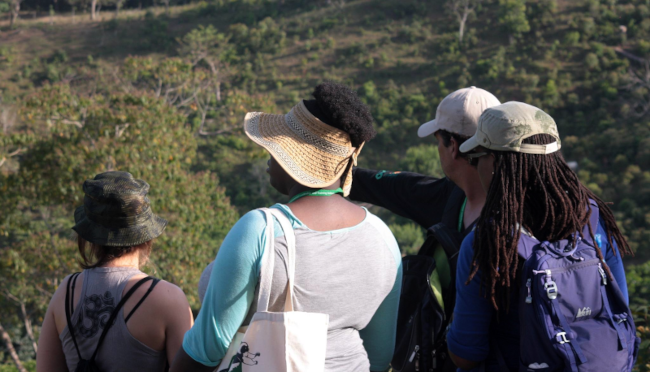

*Participantes en un curso de servicios ecosistémicos en paisajes del trópico, Panamá*

### Estudiantes de pre-grado

En general, ofrecemos temas en dos áreas: i) **ecología funcional** y ii) **macro-ecología**. Se recomienda que revisan nuestra investigación, y luego enviar un correo al dylan.craven@umayor.cl para conversar sobre posibles temas.

### Estudiantes de post-grado (PhD)

Estoy comprometido a trabajar con candidat@s a desarrollar propuestas de becas que financian sus estudios doctorales. Para chilenos, se recomienda que postulen directamente por su beca al nuevo programa de ecologia integrativa de la Universidad Mayor. Favor de enviar un correo al dylan.craven@umayor.cl **con anticipación** para discutir ideas e identificar fuentes de finaciación.

### Post-doctorantes

Buscamos a candidatos que tienen interés en desarrollar lineas de investigación complementarias a las del laboratorio, principalmente en **biogeografia funcional** o áreas afines. Estoy comprometido a trabajar con candidates a desarrollar propuestas, que sea por [FONDECYT](https://www.anid.cl/concursos/concurso/?id=281) o otro fuente de financiación.